# Social Network in the City

In this exercise I will study the social network of the town in the [Vast Challenge 2022](https://vast-challenge.github.io/2022/) dataset.

Heranshan Subramaniam https://www.linkedin.com/in/heranshan/ (School of Computing and Information Systems)https://scis.smu.edu.sg/  
2022-06-22

# Overview

In this exercise I will use visual analytic techniques to address this question:

1. What patterns can be seen from the social networks in the town?

# Getting Started

The required packages will be called with the following code chunk:

```r
packages = c('igraph', 'tidygraph',
             'ggraph', 'visNetwork',
             'lubridate', 'clock',
             'tidyverse', 'graphlayouts')

for (p in packages){
  if(!require(p, character.only = T)){
    install.packages(p)
  }
  library(p,character.only = T)
}
```

# Import Data

The SocialNetwork and ParticipantNodes data will be imported using the code chunks below:

```r
SocialNetwork <- read_csv("data/SocialNetwork.csv")
```

```r
ParticipantNodes <- read_csv("data/Participants.csv")
```

# Data Wrangling

## ParticipantNodes Changes

Change householdsize to character to use it as a category.

```r
ParticipantNodes$householdSize <- as.character(ParticipantNodes$householdSize)
```

Split age and joviality into quartiles. 1st quartile represents the lowest value and the 4th quartile represents the highest value.

```r
ParticipantNodes <- ParticipantNodes %>%
  mutate(ageQuartile = as.character(ntile(age, 4))) %>%
  mutate(jovialityQuartile = as.character(ntile(joviality, 4)))
```

Drop age and joviality columns as they are no longer needed:

```r
drop <- c("age", "joviality")

ParticipantNodes <- ParticipantNodes[, !(names(ParticipantNodes) %in% drop)]
```

Next create a day attribute for SocialNetwork data:

```r
SocialNetwork <- SocialNetwork %>%
  mutate(day = weekdays(timestamp))
```

Aggregate data to tidygraph format:

```r
SocialNetworkAggregated <- SocialNetwork %>%
  group_by(participantIdFrom, participantIdTo, day) %>%
  summarise(Weight = n()) %>%
  filter(participantIdFrom != participantIdTo) %>%
  filter(Weight>40) %>%
  ungroup()
```

Filter notes for those selected:

```r
NodesSelected <- c(SocialNetworkAggregated$participantIdFrom,
                   SocialNetworkAggregated$participantIdTo)
NodesSelected <- c(unique(NodesSelected))
```

```r
ParticipantNodesSelected <- subset(ParticipantNodes,
                                   ParticipantNodes$participantId
                                   %in% NodesSelected)
```

Create cgraph:

```r
cgraph <- graph_from_data_frame(SocialNetworkAggregated, vertices =
                                  ParticipantNodesSelected, directed = TRUE) %>%
  as_tbl_graph()
```

Activate Edges:

```r
cgraph %>%
  activate(edges) %>%
  arrange(desc(Weight))
```

```
# A tbl_graph: 648 nodes and 16658 edges
#
# A directed multigraph with 57 components
#
# Edge Data: 16,658 x 4 (active)
   from    to day       Weight
  <int> <int> <chr>      <int>
1     5    30 Thursday      65
2     5    30 Wednesday     65
3     8   384 Thursday      65
4    12   521 Thursday      65
5    13    84 Thursday      65
6    15   130 Thursday      65
# ... with 16,652 more rows
#
# Node Data: 648 x 7
  name  householdSize haveKids educationLevel interestGroup
  <chr> <chr>         <lgl>    <chr>          <chr>
1 2     3             TRUE     HighSchoolOrC~ A
2 4     3             TRUE     Bachelors      H
3 5     3             TRUE     HighSchoolOrC~ D
# ... with 645 more rows, and 2 more variables: ageQuartile <chr>,
#   jovialityQuartile <chr>
```

# Plots

## General Network Plot

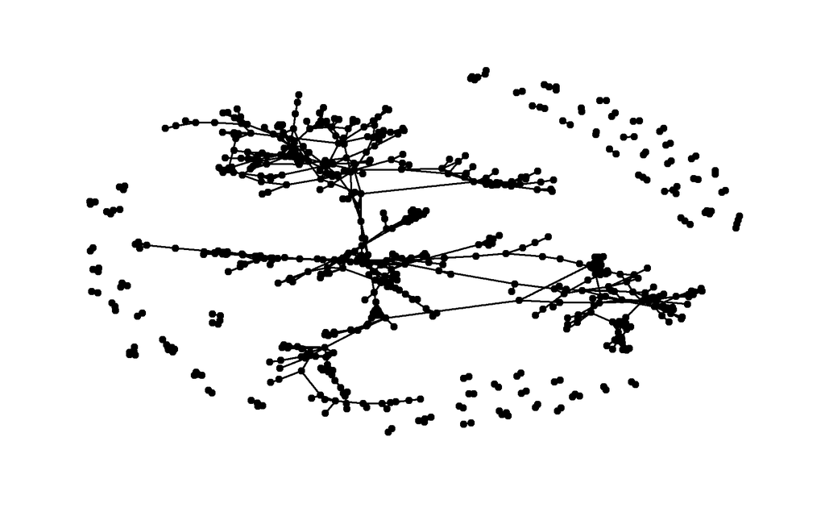

```r
g <- ggraph(cgraph,
       layout = "nicely") +
  geom_edge_link(aes()) +
  geom_node_point(aes())

g + theme_graph()
```

Observation:

It is observed from the general network plot that there are many micro networks surrounding the main network. Centrality filters will be used to clean up.

## Cumulative Frequency Plot

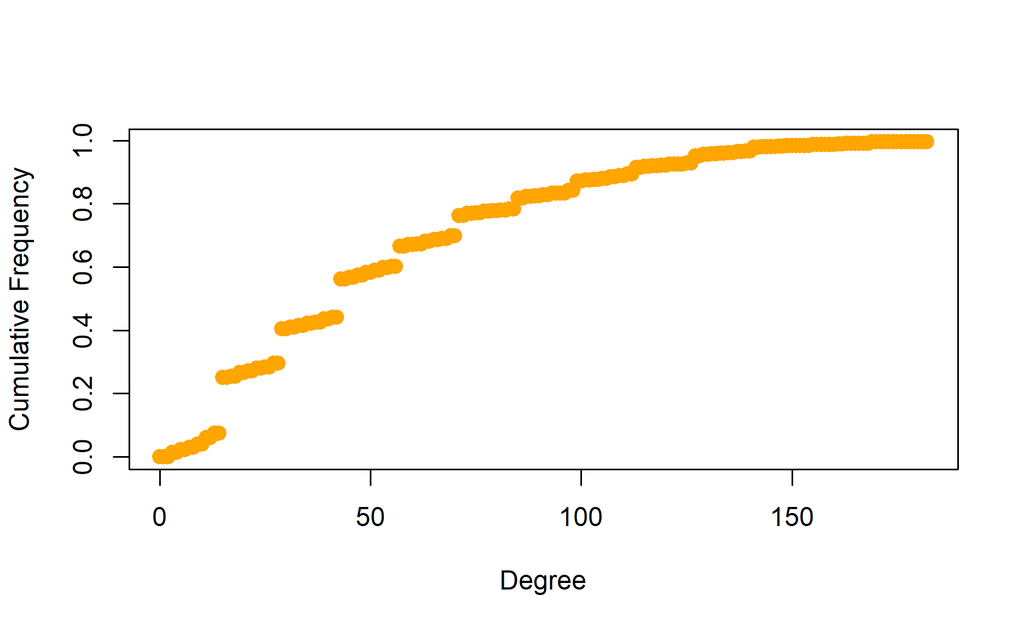

```r
deg.dist <- degree_distribution(cgraph, cumulative=T, mode="all")
plot( x=0:max(degree(cgraph)), y=1-deg.dist, pch=19, cex=1.2, col="orange",
      xlab="Degree", ylab="Cumulative Frequency")
```

## Eigenvector Centrality Plots

Eigenvector centrality measures a node’s importance while giving consideration to the importance of its neighbors. For example. a person with few connections could have a very high eigenvector centrality if those few connections were to be very well-connected others.

### Education Level

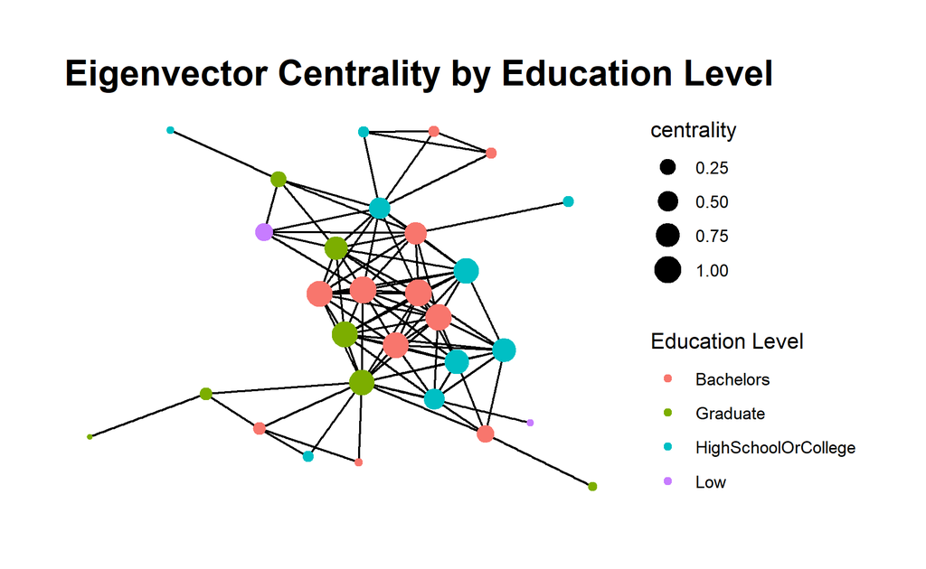

```r
cgraph %>%
    mutate(centrality = centrality_eigen()) %>%
    filter(centrality > 0.01) %>%
    ggraph(layout = 'kk') +
    geom_edge_link(aes()) +
    geom_node_point(aes(size = centrality, colour = educationLevel)) +
    labs(title = 'Eigenvector Centrality by Education Level',
         colour = "Education Level") +
    theme_graph()
```

Observation:

It can be seen that the nodes with the highest eigenvector centrality tend to be either of graduate or bachelor education level. Those of low education level tend to have low eigenvector centrality.

### Household Size

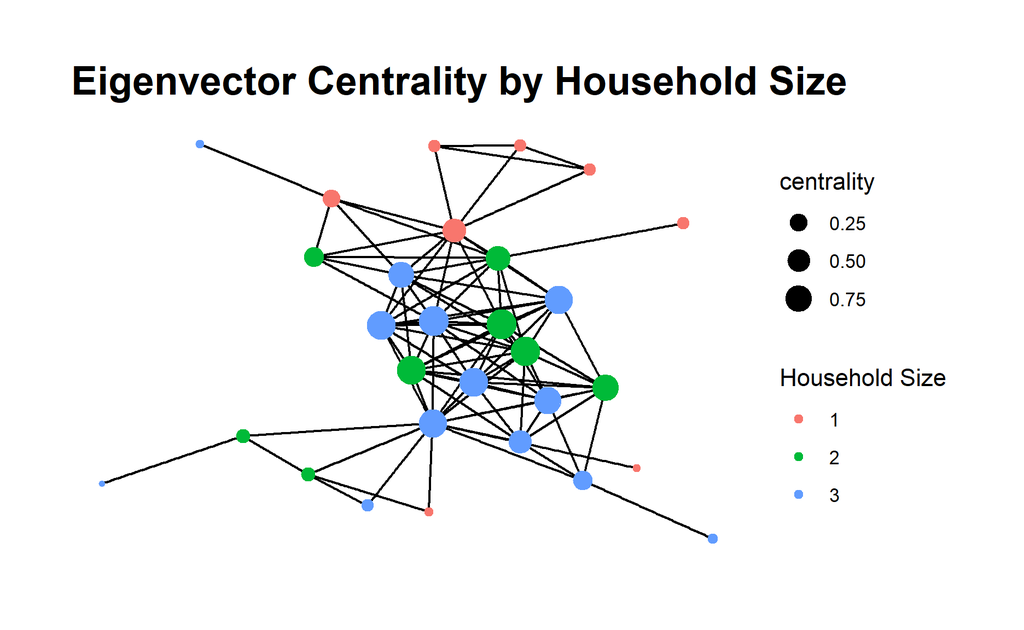

```r
cgraph %>%
    mutate(centrality = centrality_eigen()) %>%
    filter(centrality > 0.01) %>%
    ggraph(layout = 'kk') +
    geom_edge_link() +
    geom_node_point(aes(size = centrality, colour = householdSize)) +
    labs(title = 'Eigenvector Centrality by Household Size',
         colour = "Household Size") +
    theme_graph()
```

Observation:

Nodes with the highest eigenvector centrality tend to be either of household size 2 or 3. Single member households tend to have low eigenvector centrality, indicating that they are not well connected to influential nodes.

## Joviality Level

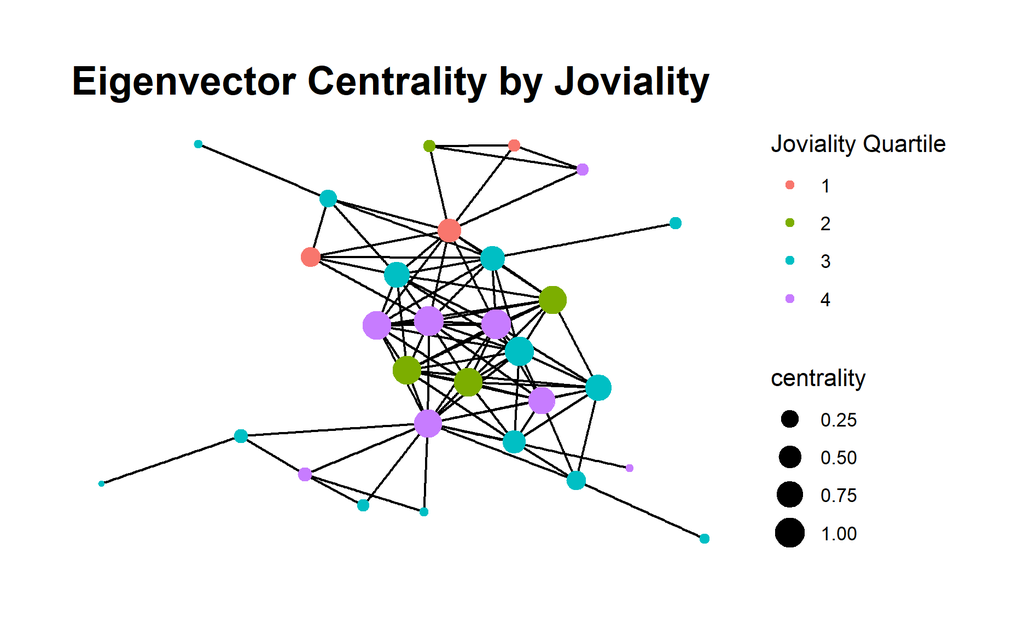

```r
cgraph %>%
    mutate(centrality = centrality_eigen()) %>%
    filter(centrality > 0.01) %>%
    ggraph(layout = 'kk') +
    geom_edge_link() +
    geom_node_point(aes(size = centrality, colour = jovialityQuartile)) +
    labs(title = 'Eigenvector Centrality by Joviality',
         colour = "Joviality Quartile") +
    theme_graph()
```

## Age Group

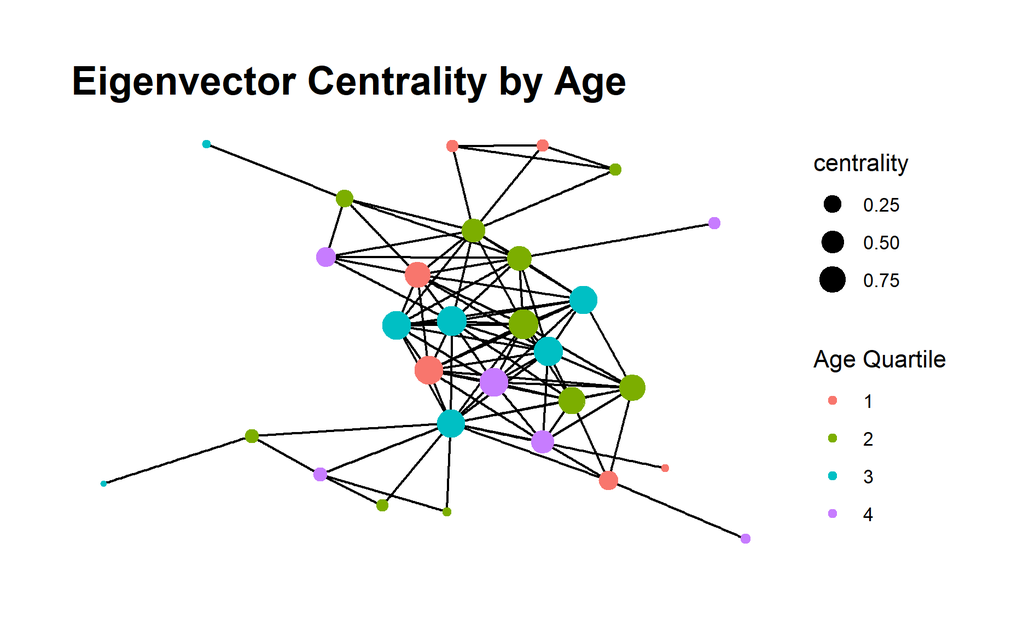

```r
cgraph %>%
    mutate(centrality = centrality_eigen()) %>%
    filter(centrality > 0.01) %>%
    ggraph(layout = 'kk') +
    geom_edge_link() +
    geom_node_point(aes(size = centrality, colour = ageQuartile)) +
    labs(title = 'Eigenvector Centrality by Age',
         colour = "Age Quartile") +
    theme_graph()
```

Observation:

The nodes with the highest eigenvector centrality tend to be those of the 2nd and 3rd age quartile. This indicates that the being too young or too old influences the connections a person has.

# Interactive Visualization

Code chunk below is used to create a new SocialNetworkAggregatedCopy

```r
SocialNetworkAggregatedCopy <- NULL
SocialNetworkAggregatedCopy <- SocialNetwork %>%
  left_join(ParticipantNodesSelected, by = c("participantIdFrom" = "participantId")) %>%
  rename(from = participantIdFrom) %>%
  left_join(ParticipantNodesSelected, by = c("participantIdTo" = "participantId")) %>%
  rename(to = participantIdTo) %>%
  group_by(from, to) %>%
    summarise(weight = n()) %>%
  filter(from!=to) %>%
  filter(weight > 150) %>%
  ungroup()
```

## Interactive Plot for Age Groups

```r
ParticipantsCopy <- ParticipantNodesSelected
names(ParticipantsCopy)[names(ParticipantsCopy) == "participantId"] <- "id"
names(ParticipantsCopy)[names(ParticipantsCopy) == "ageQuartile"] <- "group"
```

```r
visNetwork(ParticipantsCopy,
           SocialNetworkAggregatedCopy,
           height = "700px", width = "100%") %>%
  visIgraphLayout(layout = "layout_with_fr") %>%
  visOptions(highlightNearest = TRUE,
             selectedBy = "group") %>%
  visLegend()
```

[interactive chart not shown]

## Interactive Plot for Interest Group

```r
ParticipantsCopy <- ParticipantNodesSelected
names(ParticipantsCopy)[names(ParticipantsCopy) == "participantId"] <- "id"
names(ParticipantsCopy)[names(ParticipantsCopy) == "interestGroup"] <- "group"
```

```r
visNetwork(ParticipantsCopy,
           SocialNetworkAggregatedCopy,
           height = "700px", width = "100%") %>%
  visIgraphLayout(layout = "layout_with_fr") %>%
  visOptions(highlightNearest = TRUE,
             selectedBy = "group") %>%
  visLegend()
```

[interactive chart not shown]

Observation:

Participants of interest group E were the least connected to each other, indicating that this may not be a group activity.

# Areas for Improvements

1. More attributes of participants could be extracted from participant logs and studied
2. Weight would be studied further. It was not included in current plots as it made the visualizations too cluttered